# Question

Matrices $A$ and $B$ are defined below.

$$A = \begin{bmatrix}
-6 & 1 & 4\\
0 & 6 & -3\\
-7 & -8 & 3\\
1 & -5 & 5
\end{bmatrix}$$
$$B = \begin{bmatrix}
-1 & 9\\
0 & -5\\
-8 & 0
\end{bmatrix}$$

Find the [product](https://en.wikipedia.org/wiki/Matrix_multiplication) $C=AB$.

$AB=$

| ##ANSWER1## | ##ANSWER5## |
| --- | --- |
| ##ANSWER2## | ##ANSWER6## |
| ##ANSWER3## | ##ANSWER7## |
| ##ANSWER4## | ##ANSWER8## |

## Answerlist

- -59
- -41
- -30
- -26
- -23
- -17
- 24
- 34
- -59
- -41
- -30
- -26
- -23
- -17
- 24
- 34
- -59
- -41
- -30
- -26
- -23
- -17
- 24
- 34
- -59
- -41
- -30
- -26
- -23
- -17
- 24
- 34
- -59
- -41
- -30
- -26
- -23
- -17
- 24
- 34
- -59
- -41
- -30
- -26
- -23
- -17
- 24
- 34
- -59
- -41
- -30
- -26
- -23
- -17
- 24
- 34
- -59
- -41
- -30
- -26
- -23
- -17
- 24
- 34

# Solution

We wish to do matrix multiplication:

$$\begin{bmatrix}
-6 & 1 & 4\\
0 & 6 & -3\\
-7 & -8 & 3\\
1 & -5 & 5
\end{bmatrix}\begin{bmatrix}
-1 & 9\\
0 & -5\\
-8 & 0
\end{bmatrix}$$

The product matrix has 4 rows and 2 columns.

To find the product matrix’s value in row 1 and column 1, sum the products of corresponding elements of row 1 in matrix A and column 1 in matrix B.
$$C_{[1,1]}=(-6)(-1)+(1)(0)+(4)(-8)=-26$$

To find the product matrix’s value in row 1 and column 2, sum the products of corresponding elements of row 1 in matrix A and column 2 in matrix B.
$$C_{[1,2]}=(-6)(9)+(1)(-5)+(4)(0)=-59$$

To find the product matrix’s value in row 2 and column 1, sum the products of corresponding elements of row 2 in matrix A and column 1 in matrix B.
$$C_{[2,1]}=(0)(-1)+(6)(0)+(-3)(-8)=24$$

To find the product matrix’s value in row 2 and column 2, sum the products of corresponding elements of row 2 in matrix A and column 2 in matrix B.
$$C_{[2,2]}=(0)(9)+(6)(-5)+(-3)(0)=-30$$

To find the product matrix’s value in row 3 and column 1, sum the products of corresponding elements of row 3 in matrix A and column 1 in matrix B.
$$C_{[3,1]}=(-7)(-1)+(-8)(0)+(3)(-8)=-17$$

To find the product matrix’s value in row 3 and column 2, sum the products of corresponding elements of row 3 in matrix A and column 2 in matrix B.
$$C_{[3,2]}=(-7)(9)+(-8)(-5)+(3)(0)=-23$$

To find the product matrix’s value in row 4 and column 1, sum the products of corresponding elements of row 4 in matrix A and column 1 in matrix B.
$$C_{[4,1]}=(1)(-1)+(-5)(0)+(5)(-8)=-41$$

To find the product matrix’s value in row 4 and column 2, sum the products of corresponding elements of row 4 in matrix A and column 2 in matrix B.
$$C_{[4,2]}=(1)(9)+(-5)(-5)+(5)(0)=34$$

All of that work leads to the answer:

$$C = AB = \begin{bmatrix}
-26 & -59\\
24 & -30\\
-17 & -23\\
-41 & 34
\end{bmatrix}$$

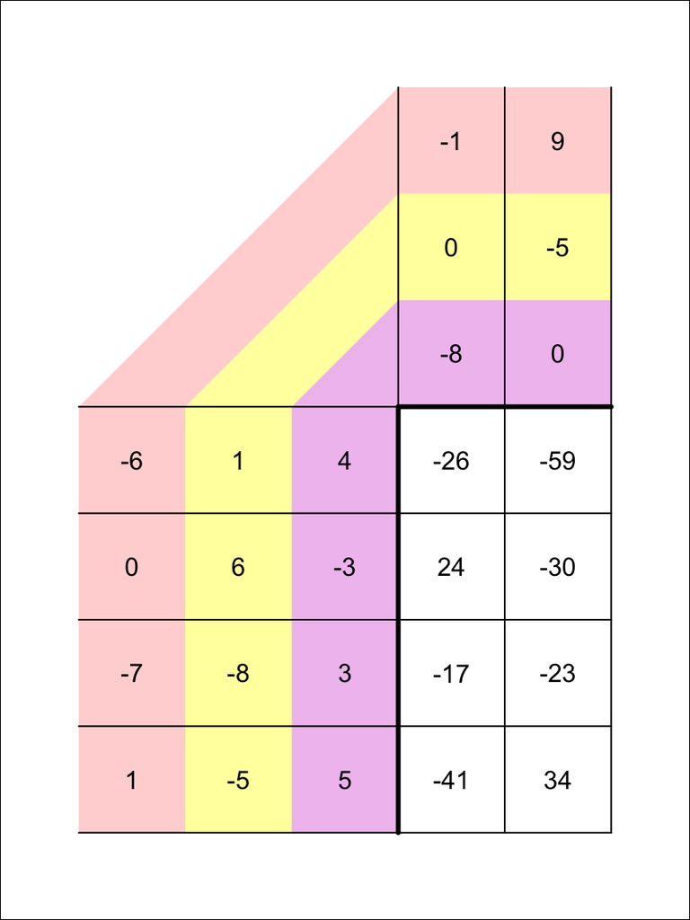

# Meta-information

extype: cloze exclozetype: schoice|schoice|schoice|schoice|schoice|schoice|schoice|schoice exsolution: 00010000|00000010|00000100|01000000|10000000|00100000|00001000|00000001 exname: mult_mats